# Laboratorio 1.1: Exploración y Visualización de Datos

Jorge Toloza, Sebastián Sepúlveda

Agosto 2019

# Instrucciones

1. Trabaje en equipos de dos personas. Salvo excepciones, no se corregirá entregas con menos de dos integrantes.
2. Modifique este archivo `.Rmd` agregando sus respuestas donde corresponda. En caso de código, cree un nuevo bloque de sentencias (chunk) para adjuntar su respuesta. Si necesita alguna explicación o fundamento, adjúntelo como texto plano.
3. Para cada pregunta, cuando corresponda, **incluya el código fuente que utilizó para llegar a su respuesta**.
4. Al final de la clase, **genere un archivo HTML usando RStudio** y súbalo a U-Cursos. Basta con que uno de los integrantes haga la entrega. Si ambos hacen una entrega en U-Cursos, se revisará cualquiera de éstas.

```r
tipos <- read.table("https://users.dcc.uchile.cl/~hsarmien/mineria/datasets/accidentes_2010_2011.txt")
head(tipos)
```

```
##    Muestra                  Descripcion Anio TipoAccidente Cantidad
## 1 Nacional                     Nacional 2010     Atropello     8247
## 2 Nacional                     Nacional 2011     Atropello     8339
## 3 Regional XV Región Arica y Parinacota 2010     Atropello      115
## 4 Regional XV Región Arica y Parinacota 2011     Atropello      159
## 5  Comunal                        ARICA 2010     Atropello      115
## 6  Comunal                        ARICA 2011     Atropello      158
```

# Parte 1

Utilizaremos un dataset *real* de número de accidentes de tránsito por localidad, el cual puede ser encontrado en el siguiente link: http://datos.gob.cl/dataset/9348. Para ello, cargue el dataset de número de accidentes de tránsito por localidad y responda las siguientes preguntas.

```r
library(readxl)
accidentes <- read_excel("INFORME DE ACCIDENTES DE TRÁNSITO PERIODO 2010 - 2011.xlsx")
head(accidentes)
```

```
## # A tibble: 6 x 14
##   Muestra `Descripcion Mu…   Año Atropello Caída Colisión Choque Volcadura
##   <chr>   <chr>            <dbl>     <dbl> <dbl>    <dbl>  <dbl>     <dbl>
## 1 Nacion… Nacional          2010      8247  1478    29127  14558      3629
## 2 Nacion… Nacional          2011      8339  1488    31487  16312      3985
## 3 Region… XV Región Arica…  2010       115     6      265    151        55
## 4 Region… XV Región Arica…  2011       159    13      426    342        68
## 5 Comunal ARICA             2010       115     6      259    142        24
## 6 Comunal ARICA             2011       158    13      414    329        38
## # … with 6 more variables: Otros <dbl>, Muertos <dbl>, `Lesionados
## #   Graves` <dbl>, `Lesionados Menos Graves` <dbl>, `Lesionados
## #   Leves` <dbl>, `(Incorporar Otra Columna Si es Necesario)` <lgl>
```

1. ¿Cuáles son las dimensiones del dataset (filas, columnas)? (Recuerde adjuntar código).

```r
# RESPUESTA
# Primero traspasamos nuestro dataset a una matriz para poder obtener los datos de una manera mas simple
mat <- as.matrix(accidentes)

#luego ocupamos las librerias de matrix para obtener el numero de filas y de columnas
nrow(mat) #numero de filas
```

```
## [1] 716
```

```r
ncol(mat) #numero de columnas
```

```
## [1] 14
```

2. ¿Qué describe cada línea del dataset? (ejemplifique tomando el dato de la fila 100). No es necesario explicar cada columna, sino más bien una idea de lo que plantea cada fila en el dataset.

```r
accidentes[100,]
```

```
## # A tibble: 1 x 14
##   Muestra `Descripcion Mu…   Año Atropello Caída Colisión Choque Volcadura
##   <chr>   <chr>            <dbl>     <dbl> <dbl>    <dbl>  <dbl>     <dbl>
## 1 Comunal RIO HURTADO       2011         0     0        0      0         2
## # … with 6 more variables: Otros <dbl>, Muertos <dbl>, `Lesionados
## #   Graves` <dbl>, `Lesionados Menos Graves` <dbl>, `Lesionados
## #   Leves` <dbl>, `(Incorporar Otra Columna Si es Necesario)` <lgl>
```

Respuesta: Considerando la fila 100 como se nos pide, vemos que los datos nos entregan una descripcion general de los accidentes ocurridos en cierto lugar del país. Nos entrega el sector principal, en este caso “RIO HURTADO”, el año en qué ocurrió el hecho, el tipo de sector con el que estamos trabajando, y los hechos ocurridos, en este caso 2 Volcaduras y 3 Lesiones leves.

3. Filtre los datos y genera un dataframe en el cual se indique la cantidad de accidentes tipo `Volcadura` que hubo en el año `2010` en cada localidad.

```r
print(accidentes[accidentes$Año==2010 & accidentes$Volcadura!=0,c("Muestra", "Descripcion Muestra" ,"Año", "Volcadura")])
```

```
## # A tibble: 329 x 4
##    Muestra  `Descripcion Muestra`          Año Volcadura
##    <chr>    <chr>                        <dbl>     <dbl>
##  1 Nacional Nacional                      2010      3629
##  2 Regional XV Región Arica y Parinacota  2010        55
##  3 Comunal  ARICA                         2010        24
##  4 Comunal  CAMARONES                     2010         5
##  5 Comunal  PUTRE                         2010        26
##  6 Regional I Región de Tarapacá          2010       158
##  7 Comunal  IQUIQUE                       2010        22
##  8 Comunal  COLCHANE                      2010         7
##  9 Comunal  HUARA                         2010        25
## 10 Comunal  PICA                          2010        25
## # … with 319 more rows
```

4. Filtre los datos para incluir sólo los accidentes ocurridos el año 2011. Genere un boxplot donde se indique la cantidad de accidentes categorizado por tipo de accidente. Este tipo de gráfico nos ayudará a entender como se distribuye los datos por cada tipo de accidentes. Es decir, podremos apreciar que tan dispersos o similares son los datos en todo el dataset. También, puede ser útil para observar valores atípicos o outliers en los datos.

```r
library("reshape")
```

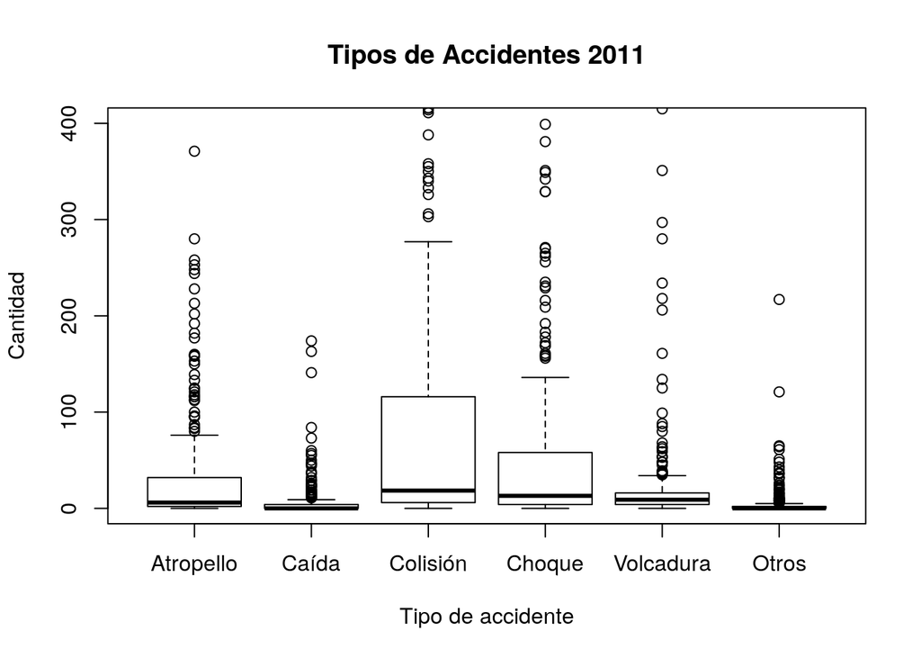

```r
library("reshape")
d <- data.frame(accidentes[1:9])
d2 <- melt(d, id=c(1,2,3))
v11 <- d2[d2$Año==2011, ]
plot(v11$variable, v11$value, ylim=c(0,400), main="Tipos de Accidentes 2011",
     xlab="Tipo de accidente", ylab="Cantidad")
```

5. ¿Qué otra forma de explorar los datos podría agregar? ¿Qué información adicional aporta? Adjunte código y breve explicación.

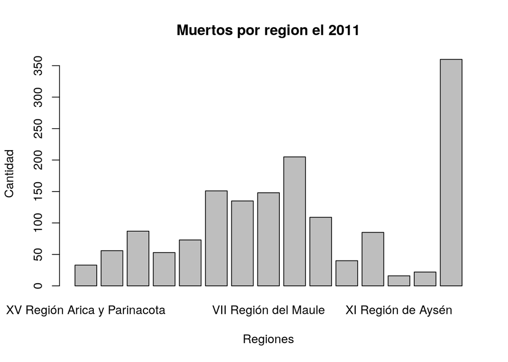

```r
d <- data.frame(accidentes[c(1,2,3, 10:13)])
v <- melt(d, id=c(1,2,3),variable_name = "Estado")
vm11 <- with(v,
                  v[ Muestra == "Regional" &
                                Año == 2011 &
                              Estado == "Muertos", ])

barplot(vm11$value, names.arg = vm11$Descripcion, main="Muertos por region el 2011",
   xlab="Regiones", ylab="Cantidad")
```

```r
print(vm11)
```

```
##      Muestra               Descripcion.Muestra  Año  Estado value
## 4   Regional      XV Región Arica y Parinacota 2011 Muertos    33
## 14  Regional              I Región de Tarapacá 2011 Muertos    56
## 30  Regional          II Región de Antofagasta 2011 Muertos    87
## 50  Regional             III Región de Atacama 2011 Muertos    53
## 70  Regional             IV Región de Coquimbo 2011 Muertos    73
## 102 Regional            V Región de Valparaíso 2011 Muertos   151
## 178 Regional VI Región del Lib. Bdo. O´Higgins 2011 Muertos   135
## 246 Regional              VII Región del Maule 2011 Muertos   148
## 308 Regional            VII Región del Bio-Bio 2011 Muertos   205
## 418 Regional         IX Región de la Araucanía 2011 Muertos   109
## 484 Regional            XIV Región de Los Ríos 2011 Muertos    40
## 510 Regional             X Región de Los Lagos 2011 Muertos    85
## 572 Regional                XI Región de Aysén 2011 Muertos    16
## 592 Regional          XII Región de Magallanes 2011 Muertos    22
## 612 Regional              Región Metropolitana 2011 Muertos   360
```

# Parte 2

Cargue el dataset de *afectados* por accidentes de tránsito y responda las siguientes preguntas.

```r
afectados <- read.table("https://users.dcc.uchile.cl/~hsarmien/mineria/datasets/afectados_2010_2011.txt")
```

1. En base al gráfico presentado más abajo ¿Sería razonable comparar la cantidad de heridos leves de la `Región Metropolitana` con la `Región de los Lagos`? ¿Por qué? Si su respuesta es negativa, proponga una forma de hacer una mejor comparación.
2. De acuerdo al siguiente gráfico ¿Qué es lo que quiere mostrar? Proponga una forma de *mejorar* este gráfico y cómo esa forma cumple mejor el objetivo de la visualización.

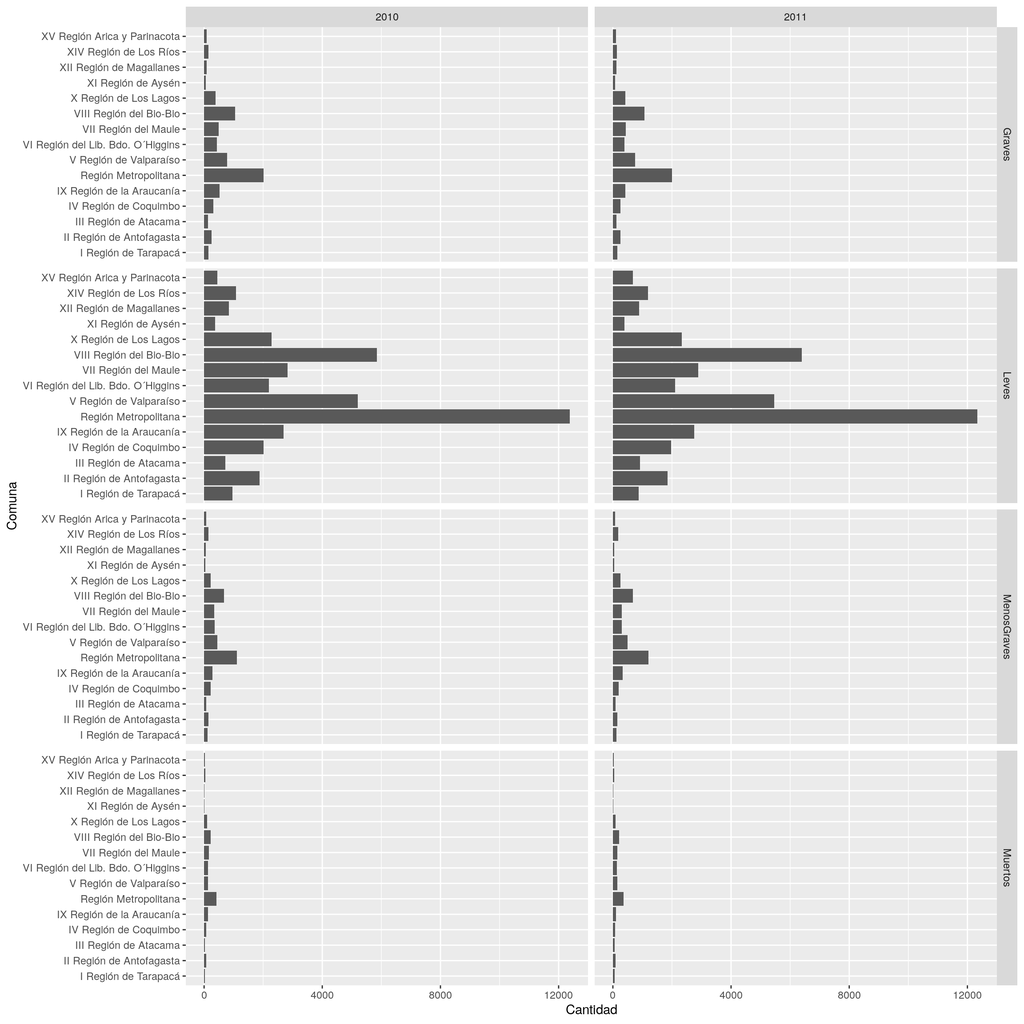

# Parte 3

Vamos a estimar la cantidad de muertos por accidente de tránsito por cada diez mil habitantes de cada comuna. Note que un accidente de tránsito puede ser Choque, Colisión, Atropello, etc.

Cargue el dataset de número de habitantes por cada comuna, obtenido a partir de datos del Censo 2002.

```r
poblacion <- read.table("https://users.dcc.uchile.cl/~hsarmien/mineria/datasets/demografico.txt", header=T)
head(poblacion)
```

```
##       Descripcion Poblacion
## 1       ALGARROBO     13011
## 2           ALHUE      4648
## 3    ALTO BIO BIO     10744
## 4 ALTO DEL CARMEN      4822
## 5   ALTO HOSPICIO     93843
## 6           ANCUD     42103
```

Además, ejecute y genere los siguientes datasets:

```r
muertosPorComuna <- with(afectados, afectados[Muestra == "Comunal" & Estado == "Muertos" & Anio == 2011, ])

tiposPorComuna <- with(tipos, tipos[Muestra == "Comunal" & Anio == 2011, ])

accidentesPorComuna <- aggregate(Cantidad ~ Descripcion, tiposPorComuna, FUN=sum)

cruceAccidentes <- merge(accidentesPorComuna, poblacion, by="Descripcion")
```

1. Explique brevemente qué datos muestran los nuevos dataframes generados: `muertosPorComuna`, `tiposPorComuna` y `accidentesPorComuna`.

```r
head(muertosPorComuna)
```

```
##    Muestra   Descripcion Anio  Estado Cantidad
## 6  Comunal         ARICA 2011 Muertos       29
## 8  Comunal     CAMARONES 2011 Muertos        2
## 10 Comunal         PUTRE 2011 Muertos        2
## 12 Comunal GENERAL LAGOS 2011 Muertos        0
## 16 Comunal       IQUIQUE 2011 Muertos       10
## 18 Comunal        CAMINA 2011 Muertos        1
```

```r
#Muestra la cantidad de muertos por cada comuna del pais el año 2011
head(tiposPorComuna)
```

```
##    Muestra   Descripcion Anio TipoAccidente Cantidad
## 6  Comunal         ARICA 2011     Atropello      158
## 8  Comunal     CAMARONES 2011     Atropello        0
## 10 Comunal         PUTRE 2011     Atropello        1
## 12 Comunal GENERAL LAGOS 2011     Atropello        0
## 16 Comunal       IQUIQUE 2011     Atropello      133
## 18 Comunal        CAMINA 2011     Atropello        1
```

```r
#Muestra el tipo de accidente con la cantidad de accidentados por cada comuna del pais el año 2011
head(accidentesPorComuna)
```

```
##       Descripcion Cantidad
## 1           AISEN       43
## 2       ALGARROBO       89
## 3           ALHUE        7
## 4    ALTO BIO BIO       10
## 5 ALTO DEL CARMEN       13
## 6   ALTO HOSPICIO      374
```

```r
#Muestra el total de accidentes que hubo en cada comuna del pais el año 2011, esto se realiza con una suma por cada tipo de accidente por comuna el año 2011 (group by en tiposPorComuna)
head(cruceAccidentes)
```

```
##       Descripcion Cantidad Poblacion
## 1           AISEN       43     26830
## 2       ALGARROBO       89     13011
## 3           ALHUE        7      4648
## 4    ALTO BIO BIO       10     10744
## 5 ALTO DEL CARMEN       13      4822
## 6   ALTO HOSPICIO      374     93843
```

```r
#Muestra la cantidad de accidentes en cada comuna y además muestra la población que hay en cada comuna, esto se realiza para obtener la proporción de accidentes por comuna por cada 10 mil habitantes
```

2. Ordene cada uno de los datasets `muertosPorComuna` y `cruceAccidentes` por el nombre de la comuna (Descripcion). Hint: Use `order`.

```r
orden_m <- muertosPorComuna[order(muertosPorComuna$Descripcion),]
orden_c <- cruceAccidentes[order(cruceAccidentes$Descripcion),]
head(orden_m)
```

```
##     Muestra     Descripcion Anio  Estado Cantidad
## 578 Comunal           AISEN 2011 Muertos        2
## 156 Comunal       ALGARROBO 2011 Muertos        1
## 700 Comunal           ALHUE 2011 Muertos        1
## 374 Comunal    ALTO BIO BIO 2011 Muertos        1
## 64  Comunal ALTO DEL CARMEN 2011 Muertos        0
## 28  Comunal   ALTO HOSPICIO 2011 Muertos       11
```

3. Genere un nuevo dataframe que contenga el nombre de la comuna y la *cantidad de muertes por cualquier tipo de accidente de tránsito* por cada diez mil habitantes en cada una de las comunas. Este último valor lo puede generar mediante la siguiente fórmula:

```r
MuertesPorAccidente = 100000 * orden_m$Cantidad / (orden_c$Cantidad * orden_c$Poblacion + 1)
muertes <- data.frame(orden_m$Descripcion, MuertesPorAccidente)
names(muertes)[1] <- "Descripcion"
head(muertes)
```

```
##       Descripcion MuertesPorAccidente
## 1           AISEN          0.17335664
## 2       ALGARROBO          0.08635728
## 3           ALHUE          3.07342410
## 4    ALTO BIO BIO          0.93074338
## 5 ALTO DEL CARMEN          0.00000000
## 6   ALTO HOSPICIO          0.03134146
```

El dataframe resultante debe verse como el siguiente ejemplo: (*Hint: Considere sección 1 y 5 del tutorial.*)

| Descripcion | MuertesPorAccidente |
| --- | --- |
| AISEN | 0.173356644 |
| ALGARROBO | 0.086357277 |
| ALHUE | 3.073424102 |
| … | … |

4. Según los datos obtenidos, genere un gráfico de barras con las top 10 comunas con mayor tasa de muertes por accidente de tránsito. *Hint: para ordenar los datos en un gráfico de barras, en ggplot use `aes(x=reorder(Descripcion, muertesPorAccidente), y=muertesPorAccidente))`.*

```r
muertesDesc <- muertes[order(muertes$MuertesPorAccidente,decreasing = TRUE),]
muertesTop <- muertesDesc[1:10,]
print(muertesTop)
```

```
##           Descripcion MuertesPorAccidente
## 285      SAN GREGORIO           64.096694
## 96          FUTALEUFU           54.990377
## 235          PUMANQUE           24.021139
## 198            PALENA           20.261372
## 42        CHILE CHICO           18.975332
## 26             CAMINA           16.832183
## 295 SAN PEDRO ATACAMA            9.237306
## 107             HUARA            8.478124
## 86          EL QUISCO            6.577108
## 307      SIERRA GORDA            6.242142
```

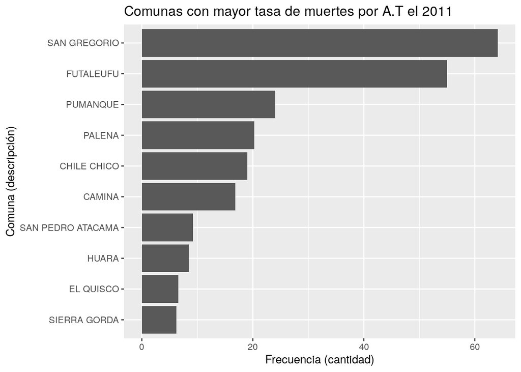

```r
library(ggplot2)  # cargamos la librería
ggplot(muertesTop) +   # asociamos un data frame a ggplot
  geom_bar(aes(x=reorder(Descripcion, MuertesPorAccidente), y=MuertesPorAccidente), stat="identity") +   # creamos un grafico de barras como una capa
  coord_flip() +  # transformamos el grafico invirtiendo los ejes de coordenadas (sólo visualmente)
  ggtitle("Comunas con mayor tasa de muertes por A.T el 2011") + # título
  xlab("Comuna (descripción)") + ylab("Frecuencia (cantidad)")  # etiquetas
```